# HW_2016122019

정민지

설치과정은 교수님 홈페이지를 참고하였습니다. https://statkclee.github.io/data-science/ds-postgreSQL.html#1_postgresql_1_2

# 1. postgreSQL 설치

- 설치 디렉토리: `C:\Program Files\PostgreSQL\12`
- 포트: 5432
- 사용자명: postgres

# 2. 예제 데이터베이스 설치

## 2.1 dvd 데이터베이스 생성

- 설치 명령어 : `CREATE DATABASE dvd;`

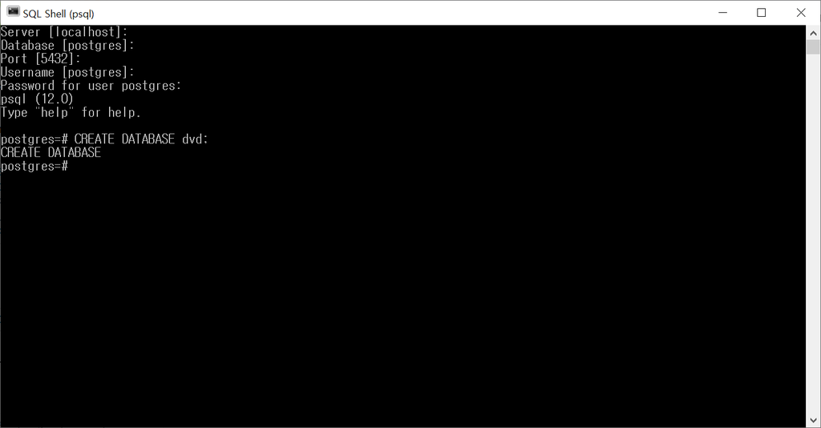

## 2.2 dvd 데이터베이스에 데이터 추가

- 디렉토리 : `C:\Program Files\PostgreSQL\12\bin`
- 설치 명령어 : `pg_restore -U postgres -d dvd C:\Users\MINJI\MJ\2019-2\Data_Engineering\HW\dvdrental.tar`

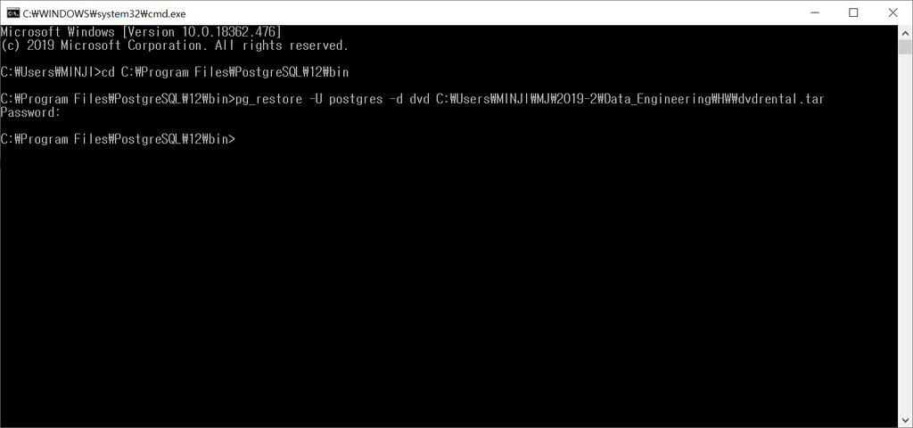

데이터 추가

[figure not shown]

pgAdmin 실행

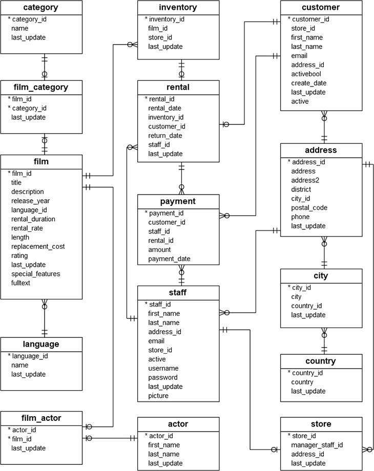

ER 다이어그램

# 3. R에서 postgreSQL 연결

- 필요한 패키지 불러오기

```r
#install.packages('RPostgreSQL')
#install.packages('DBI')
library(RPostgreSQL)
library(DBI)
library(tidyverse)
```

- PostgreSQL에 연결

```r
pgdrv <- dbDriver("PostgreSQL")

con <- dbConnect(pgdrv, dbname="dvd",
                 port="5432",
                 user="postgres",
                 password=1111,
                 host="localhost")
```

- 사용가능한 테이블 확인

```r
qry <- "SELECT *
        FROM pg_catalog.pg_tables"

dbGetQuery(con, qry) %>%
  filter(schemaname == 'public')
```

```
##    schemaname     tablename tableowner tablespace hasindexes hasrules
## 1      public         actor   postgres       <NA>       TRUE    FALSE
## 2      public         store   postgres       <NA>       TRUE    FALSE
## 3      public       address   postgres       <NA>       TRUE    FALSE
## 4      public      category   postgres       <NA>       TRUE    FALSE
## 5      public          city   postgres       <NA>       TRUE    FALSE
## 6      public       country   postgres       <NA>       TRUE    FALSE
## 7      public      customer   postgres       <NA>       TRUE    FALSE
## 8      public    film_actor   postgres       <NA>       TRUE    FALSE
## 9      public film_category   postgres       <NA>       TRUE    FALSE
## 10     public     inventory   postgres       <NA>       TRUE    FALSE
## 11     public      language   postgres       <NA>       TRUE    FALSE
## 12     public        rental   postgres       <NA>       TRUE    FALSE
## 13     public         staff   postgres       <NA>       TRUE    FALSE
## 14     public       payment   postgres       <NA>       TRUE    FALSE
```

[output cut: 17 more lines]

- 컬럼명 확인

```r
col_qry <- "SELECT table_name,
                   STRING_AGG(column_name, ', ') AS columns
            FROM information_schema.columns
            WHERE table_schema = 'public'
            GROUP BY table_name;"

dbGetQuery(con, col_qry) %>%
  DT::datatable()
```

|  | table_name | columns |
| --- | --- | --- |
| 1 | customer_list | city, notes, country, sid, address, id, zip code, name, phone |
| 2 | rental | rental_date, return_date, staff_id, last_update, inventory_id, rental_id, customer_id |
| 3 | nicer_but_slower_film_list | price, title, rating, description, fid, category, length, actors |
| 4 | film_actor | actor_id, last_update, film_id |
| 5 | sales_by_store | total_sales, store, manager |
| 6 | film | fulltext, language_id, last_update, special_features, rating, title, description, replacement_cost, rental_rate, release_year, film_id, rental_duration, length |
| 7 | customer | email, store_id, active, customer_id, last_name, activebool, last_update, first_name, create_date, address_id |
| 8 | film_category | category_id, last_update, film_id |
| 9 | actor | first_name, last_name, actor_id, last_update |
| 10 | store | address_id, store_id, last_update, manager_staff_id |

[output cut: 12 more lines]

- 모든 테이블 불러오기

```r
category <- dbGetQuery(con, "SELECT * FROM category")
film_category <- dbGetQuery(con, "SELECT * FROM film_category")
film <- dbGetQuery(con, "SELECT * FROM film")
language <- dbGetQuery(con, "SELECT * FROM language")
inventory <- dbGetQuery(con, "SELECT * FROM inventory")
rental <- dbGetQuery(con, "SELECT * FROM rental")
payment <- dbGetQuery(con, "SELECT * FROM payment")
staff <- dbGetQuery(con, "SELECT * FROM staff")
actor <- dbGetQuery(con, "SELECT * FROM actor")
customer <- dbGetQuery(con, "SELECT * FROM customer")
address <- dbGetQuery(con, "SELECT * FROM address")
city <- dbGetQuery(con, "SELECT * FROM city")
country <- dbGetQuery(con, "SELECT * FROM country")
store <- dbGetQuery(con, "SELECT * FROM store")
```

# 4. dvd 데이터 분석

모든 테이블을 원자료 그대로 불러와서 dplyr 패키지를 통해서 전처리하였다.

## Q1

What are the top and least rented (in-demand) genres and what are their total sales? (가장 많이/적게 대여된 장르는 무엇이며 그들의 총 매출액은 얼마인지 구하는 문제)

```r
Q1_qry <- "WITH t1 AS (SELECT c.name AS Genre, COUNT(cu.customer_id) AS Total_rent_demand
                      FROM category c
                      JOIN film_category fc
                      USING(category_id)
                      JOIN film f
                      USING(film_id)
                      JOIN inventory i
                      USING(film_id)
                      JOIN rental r
                      USING(inventory_id)
                      JOIN customer cu
                      USING(customer_id)
                      GROUP BY 1
                      ORDER BY 2 DESC),
              t2 AS (SELECT c.name AS Genre, SUM(p.amount) AS Total_sales
                      FROM category c
                      JOIN film_category fc
                      USING(category_id)
                      JOIN film f
                      USING(film_id)
                      JOIN inventory i
                      USING(film_id)
                      JOIN rental r
                      USING(inventory_id)
                      JOIN payment p
                      USING(rental_id)
                      GROUP BY 1
                      ORDER BY 2 DESC)
          SELECT t1.genre, t1.total_rent_demand, t2.total_sales
          FROM t1
          JOIN t2
          ON t1.genre = t2.genre;"

Q1 <- dbGetQuery(con, Q1_qry)

DT::datatable(Q1)
```

|  | genre | total_rent_demand | total_sales |
| --- | --- | --- | --- |
| 1 | Sports | 1179 | 4892.19 |
| 2 | Animation | 1166 | 4245.31 |
| 3 | Action | 1112 | 3951.84 |
| 4 | Sci-Fi | 1101 | 4336.01 |
| 5 | Family | 1096 | 3830.15 |
| 6 | Drama | 1060 | 4118.46 |
| 7 | Documentary | 1050 | 3749.65 |
| 8 | Foreign | 1033 | 3934.47 |
| 9 | Games | 969 | 3922.18 |
| 10 | Children | 945 | 3309.39 |

[output cut: 6 more lines]

```r
t1 <- left_join(category, film_category, by='category_id') %>%
  left_join(., film, by='film_id') %>%
    left_join(., inventory, by='film_id') %>%
      left_join(., rental, by='inventory_id') %>%
        left_join(., customer, by='customer_id') %>%
          select(name, customer_id) %>%
            group_by(name) %>%
              summarize(Total_rent_demand = n())

t2 <- left_join(category, film_category, by='category_id') %>%
  left_join(., film, by='film_id') %>%
    left_join(., inventory, by='film_id') %>%
      left_join(., rental, by='inventory_id') %>%
        left_join(., payment, by='rental_id') %>%
          select(name, amount) %>%
          group_by(name) %>%
            summarize(total_sales = sum(amount, na.rm = TRUE))

left_join(t1, t2, by='name') %>%
  arrange(desc(Total_rent_demand))
```

```
## # A tibble: 16 x 3
##    name        Total_rent_demand total_sales
##    <chr>                   <int>       <dbl>
##  1 Sports                   1180       4892.
##  2 Animation                1168       4245.
##  3 Action                   1115       3952.
##  4 Sci-Fi                   1103       4336.
##  5 Family                   1098       3830.
##  6 Drama                    1061       4118.
##  7 Documentary              1056       3750.
##  8 Foreign                  1039       3934.
##  9 Games                     972       3922.
## 10 Children                  947       3309.
## 11 Comedy                    943       4002.
## 12 New                       943       3966.
## 13 Classics                  942       3353.
## 14 Horror                    849       3401.
## 15 Travel                    841       3227.
## 16 Music                     830       3072.
```

- 분석 결과
1. Rent A Film은 16 종류의 장르를 가지고 있다.
2. 가장 많이 대여된 장르는 Sports이며 총매출액 또한 4892.19로 가장 높다.
3. 가장 적게 대여된 장르는 Music이며 총매출액 또한 3071.52로 가장 낮다.

## Q2

Can we know how many distinct users have rented each genre?

각 장르의 distinct한 고객수

```r
Q2_qury <- "SELECT c.name AS Genre, COUNT(DISTINCT cu.customer_id) AS Total_rent_demand_distinct
          FROM category c
          JOIN film_category fc
          USING(category_id)
          JOIN film f
          USING(film_id)
          JOIN inventory i
          USING(film_id)
          JOIN rental r
          USING(inventory_id)
          JOIN customer cu
          USING(customer_id)
          GROUP BY 1
          ORDER BY 2 DESC;"
Q2 <- dbGetQuery(con, Q2_qury)

DT::datatable(Q2)
```

|  | genre | total_rent_demand_distinct |
| --- | --- | --- |
| 1 | Sports | 519 |
| 2 | Action | 510 |
| 3 | Sci-Fi | 507 |
| 4 | Family | 501 |
| 5 | Drama | 501 |
| 6 | Animation | 500 |
| 7 | Comedy | 495 |
| 8 | Foreign | 493 |
| 9 | Documentary | 483 |
| 10 | Children | 482 |

[output cut: 6 more lines]

```r
t1 <- left_join(category, film_category, by='category_id') %>%
  left_join(., film, by='film_id') %>%
    left_join(., inventory, by='film_id') %>%
      left_join(., rental, by='inventory_id') %>%
        left_join(., customer, by='customer_id') %>%
          select(name, customer_id) %>%
            group_by(name) %>%
              summarize(Total_rent_demand = n_distinct(customer_id)) %>%
  arrange(desc(Total_rent_demand))
DT::datatable(t1)
```

|  | name | Total_rent_demand |
| --- | --- | --- |
| 1 | Sports | 520 |
| 2 | Action | 511 |
| 3 | Sci-Fi | 508 |
| 4 | Drama | 502 |
| 5 | Family | 502 |
| 6 | Animation | 501 |
| 7 | Comedy | 496 |
| 8 | Foreign | 494 |
| 9 | Documentary | 484 |
| 10 | Children | 483 |

[output cut: 6 more lines]

- 분석 결과 1번에서 Music 장르가 가장 적은 대여량을 기록했음에도 불구하고, 가장 적은 고객수를 기록하지는 않았다. Travel 장르가 가장 적은 고객수를 기록하였다.이를 통해 알 수 있는 점은 Travel 장르의 재대여횟수가 Music 장르보다 많았다는 것이다. 1번에서 총매출액과 대여량이 가장 많았던 Sports 장르는 고객수 또한 가장 많았다.

## Q3

What is the Average rental rate for each genre? (from the highest to the lowest) 각 장르의 평균대여료

```r
Q3_qry <- "SELECT c.name AS Genre, ROUND(AVG(f.rental_rate),2) AS Average_rental_rate
          FROM category c
          JOIN film_category fc
          USING(category_id)
          JOIN film f
          USING(film_id)
          GROUP BY 1
          ORDER BY 2 DESC;"
Q3 <- dbGetQuery(con, Q3_qry)
DT::datatable(Q3)
```

|  | genre | average_rental_rate |
| --- | --- | --- |
| 1 | Games | 3.25 |
| 2 | Travel | 3.24 |
| 3 | Sci-Fi | 3.22 |
| 4 | Comedy | 3.16 |
| 5 | Sports | 3.13 |
| 6 | New | 3.12 |
| 7 | Foreign | 3.1 |
| 8 | Horror | 3.03 |
| 9 | Drama | 3.02 |
| 10 | Music | 2.95 |

[output cut: 6 more lines]

- 분석결과

## Q4

How many rented films were returned late, early and on time? 반납 시기(연체/일찍/제때)에 따른 영화대여수

```r
Q4_qry <- "WITH t1 AS (SELECT *, DATE_PART('day', return_date - rental_date) AS date_difference
                      FROM rental),
          t2 AS (SELECT rental_duration, date_difference,
                        CASE
                          WHEN rental_duration > date_difference THEN 'Returned early'
                          WHEN rental_duration = date_difference THEN 'Returned on Time'
                          ELSE 'Returned late'
                        END AS Return_status
                  FROM film f
                  JOIN inventory i
                  USING(film_id)
                  JOIN t1
                  USING(inventory_id))
          SELECT Return_status, COUNT(*) AS total_no_of_films
          FROM t2
          GROUP BY 1
          ORDER BY 2 DESC;"
Q4 <- dbGetQuery(con, Q4_qry)
DT::datatable(Q4)
```

|  | return_status | total_no_of_films |
| --- | --- | --- |
| 1 | Returned early | 7738 |
| 2 | Returned late | 6586 |
| 3 | Returned on Time | 1720 |

- 분석 결과 The return status of movies is arguably is one the most important aspects to monitor in a DVD rental business. From the above query, 48% of the movies are returned earlier than the due date while 41% of the movies are returned late and 11% arrive on time.

There could be a number of factors for why this could be happening, like the shipping distance of these movies from stores which could be totally out of the control of the customers and so on. We would need to dive deeper into the data to get the gist of the issue.

However, it is wise to note that a significant percentage of movies are returned late. Introducing a penalty fee for late arrival could be an extra source of income and in turn, discourage late returns.

But such a decision can only make sense if we know why the issue is occurring.

## Q5

In which countries do Rent A Film have a presence in and what is the customer base in each country? What are the total sales in each country? (From most to least) (Rent A Film이 입점한 국가와 고객들의 국가 / 각 국가에 대한 총매출액)

```r
Q5_qry <- "SELECT country,
                COUNT(DISTINCT customer_id) AS customer_base,
                SUM(amount) AS total_sales
          FROM country
          JOIN city
          USING(country_id)
          JOIN address
          USING(city_id)
          JOIN customer
          USING(address_id)
          JOIN payment
          USING(customer_id)
          GROUP BY 1
          ORDER BY 2 DESC, 3 DESC;"
Q5 <- dbGetQuery(con, Q5_qry)
DT::datatable(Q5)
```

|  | country | customer_base | total_sales |
| --- | --- | --- | --- |
| 1 | India | 60 | 6034.78 |
| 2 | China | 53 | 5251.03 |
| 3 | United States | 36 | 3685.31 |
| 4 | Japan | 31 | 3122.51 |
| 5 | Mexico | 30 | 2984.82 |
| 6 | Brazil | 28 | 2919.19 |
| 7 | Russian Federation | 28 | 2765.62 |
| 8 | Philippines | 20 | 2219.7 |
| 9 | Turkey | 15 | 1498.49 |
| 10 | Indonesia | 14 | 1352.69 |

[output cut: 98 more lines]

- 분석 결과

Rent A Film has a presence in 108 countries with India having the highest customer base of 60 customers and the largest total sales in terms of money. Afghanistan has the smallest total sales in terms of money, even though it is not the only country with the smallest customer base of 1 customer

## Q6

Who are the top 5 customers per total sales and can we get their detail just in case Rent A Film wants to reward them? (총매출액이 가장 높은 5명의 고객을 파악하고 그들에게 보상할 때 필요한 세부 정보 파악하기)

```r
Q6_qry <- "WITH t1 AS (SELECT *,
                            first_name || ' ' || last_name AS full_name
                      FROM customer)
          SELECT full_name,
                  email,
                  address,
                  phone,
                  city,
                  country,
                  SUM(amount) AS total_purchase_in_currency
          FROM t1
          JOIN address
          USING(address_id)
          JOIN city
          USING(city_id)
          JOIN country
          USING(country_id)
          JOIN payment
          USING(customer_id)
          GROUP BY 1,2,3,4,5,6
          ORDER BY 7 DESC
          LIMIT 5;"
Q6 <- dbGetQuery(con, Q6_qry)
DT::datatable(Q6)
```

|  | full_name | email | address | phone | city | country | total_purchase_in_currency |
| --- | --- | --- | --- | --- | --- | --- | --- |
| 1 | Eleanor Hunt | eleanor.hunt@sakilacustomer.org | 1952 Pune Lane | 354615066969 | Saint-Denis | Runion | 211.55 |
| 2 | Karl Seal | karl.seal@sakilacustomer.org | 1427 Tabuk Place | 214756839122 | Cape Coral | United States | 208.58 |
| 3 | Marion Snyder | marion.snyder@sakilacustomer.org | 1891 Rizhao Boulevard | 391065549876 | Santa Brbara dOeste | Brazil | 194.61 |
| 4 | Rhonda Kennedy | rhonda.kennedy@sakilacustomer.org | 1749 Daxian Place | 963369996279 | Apeldoorn | Netherlands | 191.62 |
| 5 | Clara Shaw | clara.shaw@sakilacustomer.org | 1027 Songkhla Manor | 563660187896 | Molodetno | Belarus | 189.6 |

- 분석 결과

Assuming we wish to reward or send physical gifts to the top customers, the above table shows their full names, addresses, email etc.

This information can be sent to the marketing team of the company in order to use their domain knowledge to decide how to reward them.

## 4.8 최종 결론

In this project, we analyzed data from a DVD rental company we decided to call ‘Rent A Film’ to find insights about the customers and their preference. We got 3 major conclusions:

```r
DBI::dbDisconnect(con)
```

```
## [1] TRUE
```